# Linear Mixed-Effects Model Summary

08 February, 2025, 11:02

Let’s investigate our data to see what the numbers can tell us about eating fish and eating sugar and how both relate to happiness scores and incidences of anxiety & depressive disorders across many countries around the world.

*Remember: not all countries were represented in each data set collected, and when refining some were lost. This means not all countries are accounted for in this investigation, though 150 countries is no small number*

## Initial imports

**First we’ll import the libraries we’re going to use.**

```r
here::i_am("notebooks/calculations.Rmd")
```

```
## here() starts at /Users/drewrichard/Documents/projects/nss/nss_projects/world_happiness_ar
```

```r
shh <- suppressPackageStartupMessages
shh(library(here))
shh(library(tidyverse))
shh(library(broom.mixed))
shh(library(lme4))
shh(library(ggeffects))
shh(library(performance))
shh(library(plotly))
```

#### Next we’ll import our data.

*You’ll notice that the data has already been cleaned and arranged in a way that makes the following operations straightforward. The original data files are available from their sources (linked on the home page), or in the github repository.*

```r
data <- tibble(read_csv(here('data/happy_sad_sugar_fish.csv'))) |>
  arrange(country) |>
  select(country, year, happiness_score, fish_consumption=fish_kg_per_person_per_year, sugar_consumption = sugar_g_per_person_per_day, sadness_score = pct_new_per_pop_disorders)
data
```

```
## # A tibble: 1,600 × 6
##    country      year happiness_score fish_consumption sugar_consumption
##    <chr>       <dbl>           <dbl>            <dbl>             <dbl>
##  1 Afghanistan  2008            37.2             0.08              23.4
##  2 Afghanistan  2009            44               0.07              23.3
##  3 Afghanistan  2010            47.6             0.07              24.2
##  4 Afghanistan  2011            38.3             0.07              24.8
##  5 Afghanistan  2012            37.8             0.07              25.4
##  6 Afghanistan  2013            35.7             0.07              24.5
##  7 Afghanistan  2014            31.3             0.19              34.7
##  8 Afghanistan  2015            39.8             0.21              32.6
##  9 Afghanistan  2016            42.2             0.23              29.9
## 10 Afghanistan  2017            26.6             0.25              32.6
## # ℹ 1,590 more rows
## # ℹ 1 more variable: sadness_score <dbl>
```

## Modeling the data

Linear mixed effects regression models are used when not all observations are independent incorporating variables that have both fixed effects and random effects.

In our case, the **fixed effects predictors** are `fish_consumption`, `sugar_consumption`, and `year`. The **random effects predictor** is `country`. The target variable is either the `happiness_score` or the `sadness_score`.

We’ll use the `lmer` package to evaluate.

```r
mixed_model <- lmer(
  happiness_score ~ year + sugar_consumption +
    fish_consumption + (1 | country),
  data = data)
summary(mixed_model)
```

```
## Linear mixed model fit by REML ['lmerMod']
## Formula: happiness_score ~ year + sugar_consumption + fish_consumption +
##     (1 | country)
##    Data: data
##
## REML criterion at convergence: 9489.4
##
## Scaled residuals:
##     Min      1Q  Median      3Q     Max
## -5.5305 -0.5675  0.0132  0.5632  4.7850
##
## Random effects:
##  Groups   Name        Variance Std.Dev.
##  country  (Intercept) 91.97    9.590
##  Residual             14.87    3.856
## Number of obs: 1600, groups:  country, 150
##
## Fixed effects:
##                    Estimate Std. Error t value
## (Intercept)       -0.048114  56.500736  -0.001
## year               0.025223   0.028171   0.895
## sugar_consumption  0.017764   0.004474   3.971
## fish_consumption   0.113243   0.036758   3.081
##
## Correlation of Fixed Effects:
##             (Intr) year   sgr_cn
## year        -1.000
## sgr_cnsmptn  0.325 -0.331
## fsh_cnsmptn  0.098 -0.108 -0.012
```

#### Random Effects

```
Random effects:
Groups   Name        Variance Std.Dev.
country  (Intercept) 91.97    9.590
Residual             14.87    3.856
Number of obs: 1600, groups:  country, 150
```

The variance between countries ($91.97$) is much larger than the residual variance, suggesting that **there are substantial differences in baseline happiness between countries**.

- this means that the difference in country accounts for much more of the variation in happiness score than the unexplained variation within countries.
- the ratio $91.97/(91.97 + 14.87) = 0.86$ suggests that around $86%$ of the variation in happiness scores (after accounting for the fixed effects) is explained by differences in baseline happiness by country.

#### Fixed Effects

```
Fixed effects:
Estimate Std. Error t value
(Intercept)       -0.048114  56.500736  -0.001
year               0.025223   0.028171   0.895
sugar_consumption  0.017764   0.004474   3.971
fish_consumption   0.113243   0.036758   3.081
```

We gain some interesting insight when looking at the fixed effects. There is a positive association between `year`, `sugar_consumption`, and `fish_consumption`.

The $t-values$ (calculated as $t = Estimate / Std. Error$) will tell us what is statistically significant and what is not. As a rule of thumb, when using mixed effects models:

- $|t| > 2$ suggests statistical significance at approximately the $p = 0.05$ level.
- $|t| > 2.6$ suggests significance at approximately the $p = 0.01$ level.
- $|t| > 3.3$ suggests significance at approximately the $p = 0.001$ level.

Based on the $t$ values, we conclude that `year` is **not** statistically significant, `fish_consumption` is **very** statistically significant, and `sugar_consumption` is **highly** statistically significant.

All of this is well visualized in the plots below which show the predicted values and confidence intervals.

## Model Visualization

We can visualize using `ggplot2` and `ggpredict`.

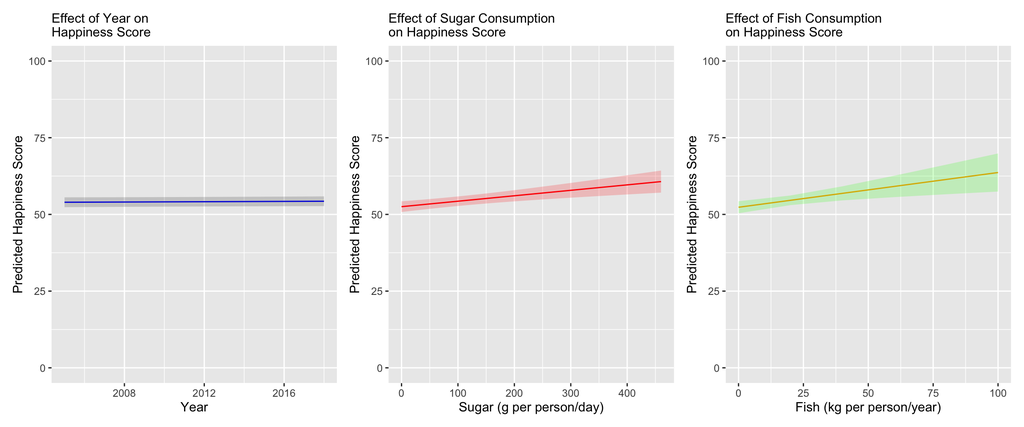

```r
# Extract predictions while varying one predictor at a time
effects_year  <- ggpredict(mixed_model, terms = "year")
effects_sugar <- ggpredict(mixed_model, terms = "sugar_consumption")
effects_fish  <- ggpredict(mixed_model, terms = "fish_consumption")

# Plot each effect separately
plot1 <- ggplot(effects_year, aes(x = x, y = predicted)) +
  geom_line(color = "blue") +
  geom_ribbon(aes(ymin = conf.low, ymax = conf.high), alpha = 0.2) +
  labs(title = "Effect of Year on\nHappiness Score",
       x = "Year",
       y = "Predicted Happiness Score") +
  scale_y_continuous(limits=c(0,100))+
  scale_x_continuous(limits=c(2005,2018))+
  theme(plot.title = element_text(size=11))

plot2 <- ggplot(effects_sugar, aes(x = x, y = predicted)) +
  geom_line(color = "red") +
  geom_ribbon(aes(ymin = conf.low, ymax = conf.high),
              alpha = 0.2, fill = "red") +
  labs(title = "Effect of Sugar Consumption\non Happiness Score",
       x = "Sugar (g per person/day)",
       y = "Predicted Happiness Score")+
  scale_y_continuous(limits=c(0,100))+
  theme(plot.title = element_text(size=11))

plot3 <- ggplot(effects_fish, aes(x = x, y = predicted)) +
  geom_line(color = "orange") +
  geom_ribbon(aes(ymin = conf.low, ymax = conf.high),
              alpha = 0.2, fill = "green") +
  labs(title = "Effect of Fish Consumption\non Happiness Score",
       x = "Fish (kg per person/year)",
       y = "Predicted Happiness Score") +
  scale_y_continuous(limits=c(0,100))+
  theme(plot.title = element_text(size=11))

# Arrange plots in a grid
library(patchwork)
plot1 + plot2 + plot3
```

The year plot shows us a very small increase in predicted happiness over time, with fairly high confidence (small ribbon), though we know this is not statistically significant already. The sugar plot shows us a reasonable increase in predicted happiness with an increase in average sugar consumption and we know with reasonably high confidence that this is statistically significant. Finally the fish plot shows us the largest increase in predicted happiness score with an increase in fish consumption, though the confidence interval is slightly larger than on the sugar plot.

## Random effects plot

The following plot can be used to visualize baseline happiness by country after controlling for our fixed effects.

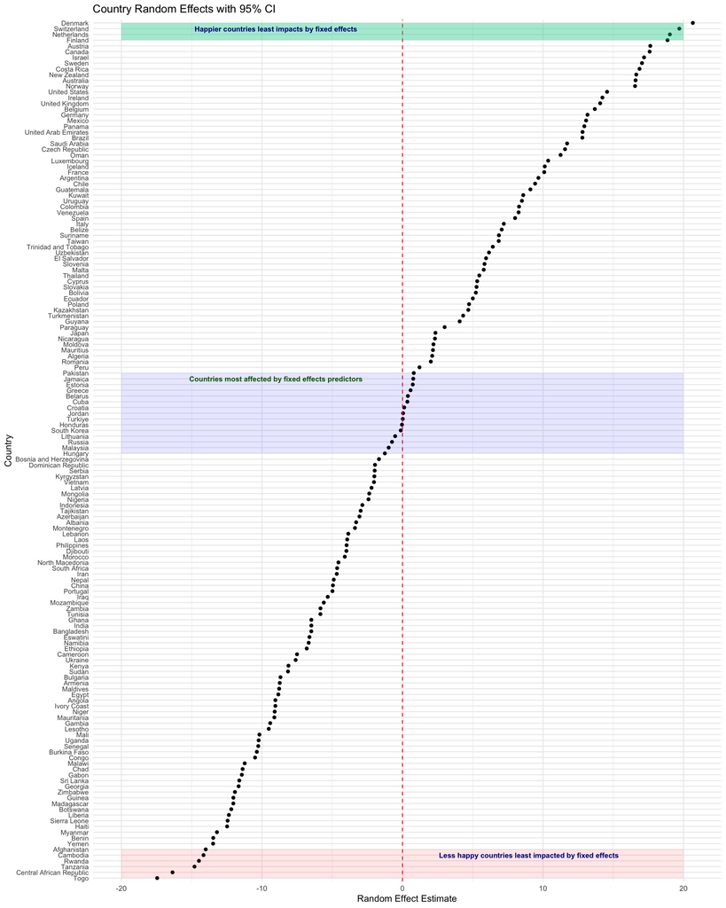

```r
# Get random effects
ranef_df <- ranef(mixed_model)$country %>%
  as.data.frame() %>%
  rownames_to_column("country") %>%
  rename(effect = "(Intercept)") %>%
  arrange(effect)

# Plot random effects with confidence intervals
ggplot(ranef_df, aes(y = reorder(country, effect), x = effect)) +
  geom_point() +
  geom_vline(xintercept = 0, linetype = "dashed", color = "red") +
  theme_minimal() +
  labs(x = "Random Effect Estimate", y = "Country",
       title = "Country Random Effects with 95% CI")+
  annotate("rect", xmin = -20, xmax=20, ymin="Finland", ymax="Denmark", alpha = .4,fill = "#00CC96")+
  annotate("text", x = -9, y = "Switzerland", label = "Happier countries least impacts by fixed effects",
           fontface = "bold", colour = "darkblue", size = 3)+
  annotate("rect", xmin = -20, xmax=20, ymin="Hungary", ymax="Pakistan", alpha = .1,fill = "blue")+
  annotate("text", x = -9, y = "Jamaica", label = "Countries most affected by fixed effects predictors",
           fontface = "bold", colour = "darkgreen", size = 3)+
  annotate("rect", xmin = -20, xmax=20, ymin="Togo", ymax="Afghanistan", alpha = .1,fill = "red")+
  annotate("text", x = 9, y = "Cambodia", label = "Less happy countries least impacted by fixed effects",
           fontface = "bold", colour = "darkblue", size = 3)+
  theme(axis.text.y = element_text(size = 8))
```

This is a caterpillar plot or forest plot. It visually represents the estimated random intercepts for each country.

- **Values to the right of zero (positive values)**: Countries with positive random effect estimates (points to the right of the red dashed line) have a higher intercept than the average intercept in the model. In simpler terms, after accounting for `year`, `sugar_consumption`, and `fish_consumption`, these countries tend to have a higher baseline happiness score compared to the average country in this dataset.
- **Values to the left of zero (negative values)**: Countries with negative random effect estimates (points to the left of the red dashed line) have a lower intercept than the average intercept. They tend to have a lower baseline happiness score than the average country, even after considering the fixed effects.
- **Values close to zero**: Countries with random effects close to zero have baseline happiness scores that are very close to the average baseline happiness score, after accounting for the fixed effects. *Their happiness is already well-explained by the fixed predictors in the model, and there’s not much country-specific deviation from the average intercept needed.* These countries are the ones whose variation in happiness score can be better explained by our variables of interest.

## Modeling the data

```r
mixed_model <- lmer(
  sadness_score ~ year + sugar_consumption +
    fish_consumption + (1 | country),
  data = data, REML = TRUE)
summary(mixed_model)
```

```
## Linear mixed model fit by REML ['lmerMod']
## Formula: sadness_score ~ year + sugar_consumption + fish_consumption +
##     (1 | country)
##    Data: data
##
## REML criterion at convergence: -19664.8
##
## Scaled residuals:
##     Min      1Q  Median      3Q     Max
## -5.8894 -0.4066 -0.0440  0.3594  5.1828
##
## Random effects:
##  Groups   Name        Variance  Std.Dev.
##  country  (Intercept) 1.191e-05 0.0034514
##  Residual             1.356e-07 0.0003683
## Number of obs: 1600, groups:  country, 150
##
## Fixed effects:
##                     Estimate Std. Error t value
## (Intercept)       -9.196e-02  5.460e-03 -16.840
## year               5.090e-05  2.723e-06  18.696
## sugar_consumption -8.327e-07  4.436e-07  -1.877
## fish_consumption   2.336e-05  4.745e-06   4.923
##
## Correlation of Fixed Effects:
##             (Intr) year   sgr_cn
## year        -0.999
## sgr_cnsmptn  0.340 -0.347
## fsh_cnsmptn  0.140 -0.155  0.031
```

#### Random effects

```
Random effects:
Groups   Name        Variance  Std.Dev.
country  (Intercept) 1.191e-05 0.0034514
Residual             1.356e-07 0.0003683
Number of obs: 1600, groups:  country, 150
```

We have some very interesting results from this model.

- the variance between countries is very small, and residual variance even smaller. This tells us there is very little variation in country-level baseline sadness score.
- we know the scale is significantly smaller with this model due to the way the scores were calculated in comparison to the happiness scores, so we’ll need to keep that in mind when interpreting the fixed effects.

#### Fixed Effects

```
Fixed effects:
Estimate Std. Error t value
(Intercept)       -9.196e-02  5.460e-03 -16.840
year               5.090e-05  2.723e-06  18.696
sugar_consumption -8.327e-07  4.436e-07  -1.877
fish_consumption   2.336e-05  4.745e-06   4.923
```

We see a very strongly negative $t-value$ for the `Intercept`, and a very strongly positive $t-value$ for `year`. Both of these are statistically singnificant to a very high degree. While `fish_consumption` is also statistically significant with $t = 4.923$, the much larger $t-values$ for the `Intercept` and `year` mean that the effect that `fish_consumption` has on the `sadness_score` is much smaller (though again, still statistically significant).

All of this is well visualized in the plots below which show the predicted values and confidence intervals.

## Model Visualization

We can visualize using `ggplot2` and `ggpredict`.

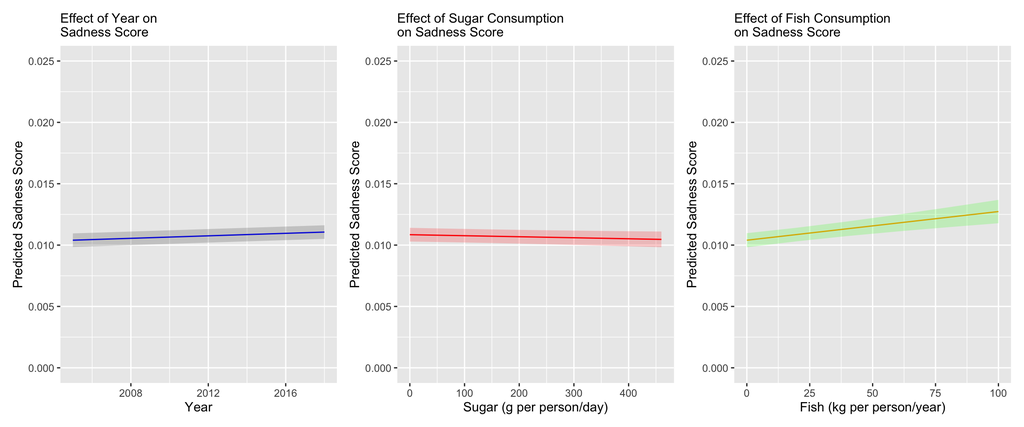

```r
# Extract predictions while varying one predictor at a time
effects_year  <- ggpredict(mixed_model, terms = "year")
effects_sugar <- ggpredict(mixed_model, terms = "sugar_consumption")
effects_fish  <- ggpredict(mixed_model, terms = "fish_consumption")

# Plot each effect separately
plot1 <- ggplot(effects_year, aes(x = x, y = predicted)) +
  geom_line(color = "blue") +
  geom_ribbon(aes(ymin = conf.low, ymax = conf.high), alpha = 0.2) +
  labs(title = "Effect of Year on\nSadness Score",
       x = "Year",
       y = "Predicted Sadness Score") +
  scale_y_continuous(limits=c(0,.025))+
  scale_x_continuous(limits=c(2005,2018))+
  theme(plot.title = element_text(size=11))

plot2 <- ggplot(effects_sugar, aes(x = x, y = predicted)) +
  geom_line(color = "red") +
  geom_ribbon(aes(ymin = conf.low, ymax = conf.high),
              alpha = 0.2, fill = "red") +
  labs(title = "Effect of Sugar Consumption\non Sadness Score",
       x = "Sugar (g per person/day)",
       y = "Predicted Sadness Score")+
  scale_y_continuous(limits=c(0,.025))+
  theme(plot.title = element_text(size=11))

plot3 <- ggplot(effects_fish, aes(x = x, y = predicted)) +
  geom_line(color = "orange") +
  geom_ribbon(aes(ymin = conf.low, ymax = conf.high),
              alpha = 0.2, fill = "green") +
  labs(title = "Effect of Fish Consumption\non Sadness Score",
       x = "Fish (kg per person/year)",
       y = "Predicted Sadness Score") +
  scale_y_continuous(limits=c(0,.025))+
  theme(plot.title = element_text(size=11))

# Arrange plots in a grid
library(patchwork)
plot1 + plot2 + plot3
```

## Random effects plot

The following plot can be used to visualize baseline sadness scores by country after controlling for our fixed effects.

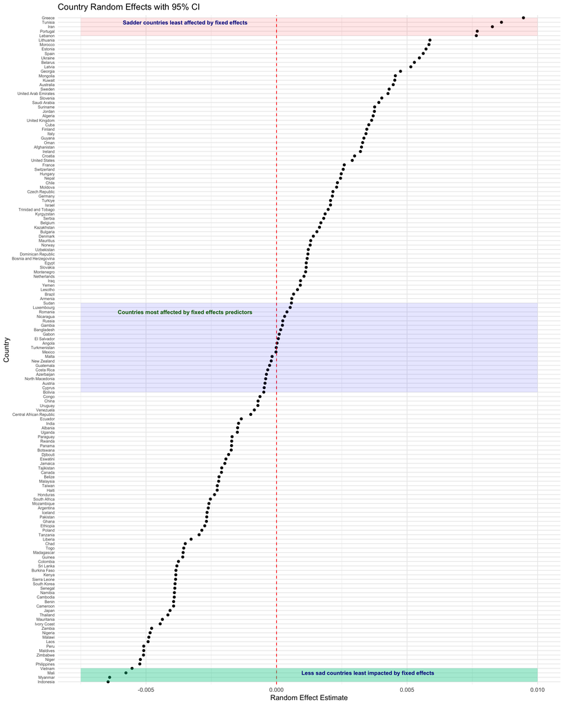

```r
# Get random effects
ranef_df <- ranef(mixed_model)$country %>%
  as.data.frame() %>%
  rownames_to_column("country") %>%
  rename(effect = "(Intercept)") %>%
  arrange(effect)

# Plot random effects with confidence intervals
ggplot(ranef_df, aes(y = reorder(country, effect), x = effect)) +
  geom_point() +
  geom_vline(xintercept = 0, linetype = "dashed", color = "red") +
  theme_minimal() +
  labs(x = "Random Effect Estimate", y = "Country",
       title = "Country Random Effects with 95% CI")+
  annotate("rect", xmin = -.0075, xmax=.01, ymin="Lebanon", ymax="Greece", alpha = .1,fill = "red")+
  annotate("text", x = -.0035, y = "Tunisia", label = "Sadder countries least affected by fixed effects",
           fontface = "bold", colour = "darkblue", size = 3)+
  annotate("rect", xmin = -.0075, xmax=.01, ymin="Bolivia", ymax="Sudan", alpha = .1,fill = "blue")+
  annotate("text", x = -.0035, y = "Romania", label = "Countries most affected by fixed effects predictors",
           fontface = "bold", colour = "darkgreen", size = 3)+
  annotate("rect", xmin = -.0075, xmax=0.01, ymin="Indonesia", ymax="Vietnam", alpha = .4,fill = "#00CC96")+
  annotate("text", x = .0035, y = "Mali", label = "Less sad countries least impacted by fixed effects",
           fontface = "bold", colour = "darkblue", size = 3)+
  theme(axis.text.y = element_text(size = 6))
```

## Further analysis

Below is some further analysis which will have less explanation, and can be used and interpreted as the reader decides.

```r
# the scale() function works like the function written below
# z_score <- function(x){
#   m <- mean(data$happiness_score) # sample mean
#   sig <- sd(data$happiness_score) # sample standard deviation
#   z <- (x-m)/sig # calculate z-score
#   return(z)
# }

data <- data |>
  mutate(happy_z = scale(data$happiness_score),
         sad_z = scale(data$sadness_score))
```

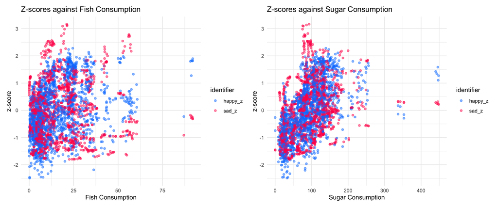

```r
fish_z <- data |>
  pivot_longer(
    cols = c(happy_z, sad_z),
    names_to = "identifier",
    values_to = "zscore"
  ) |>
  ggplot(aes(x=fish_consumption, y= zscore, color = identifier)) +
  geom_point(alpha = 0.5) +
  labs(
    title = "Z-scores against Fish Consumption",
    x= "Fish Consumption",
    y="z-score"
  )+
  scale_color_manual(
    values = c(
      "happy_z" = "#007fff",
      "sad_z" = "#ff1d58"
    )) +
  # geom_smooth(method="lm") +
  # annotate("text", "linear model w/ 95% C.I.") +
  theme_minimal()

sugar_z <- data |>
  pivot_longer(
    cols = c(happy_z, sad_z),
    names_to = "identifier",
    values_to = "zscore"
  ) |>
  ggplot(aes(x=sugar_consumption, y= zscore, color = identifier)) +
  geom_point(alpha = 0.5) +
  labs(
    title = "Z-scores against Sugar Consumption",
    x= "Sugar Consumption",
    y="z-score"
  )+
  scale_color_manual(
    values = c(
      "happy_z" = "#007fff",
      "sad_z" = "#ff1d58"
    )) +
  # geom_smooth(method="lm") +
  # annotate("text", "linear model w/ 95% C.I.") +
  theme_minimal()

fish_z + sugar_z
```

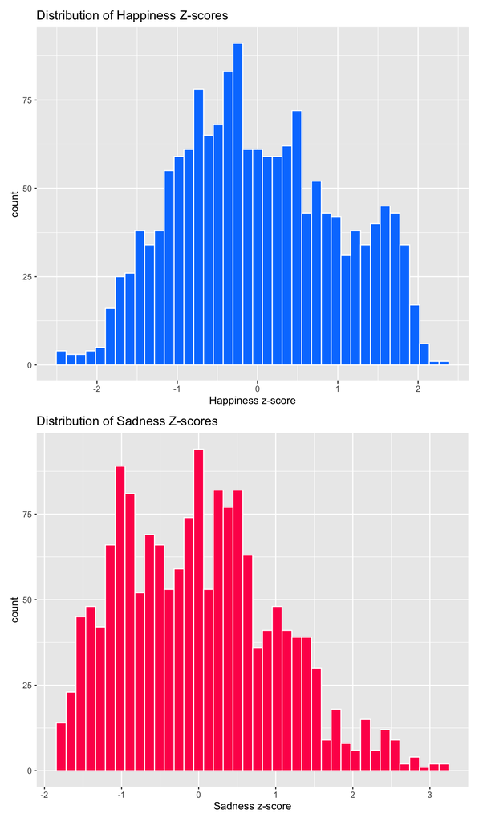

```r
happy_z_dist <- ggplot(data, aes(x=happy_z))+
  geom_histogram(bins = 40, fill = "#007fff", color = "white") +
  labs(
    title = "Distribution of Happiness Z-scores",
    x= "Happiness z-score"
  )
sad_z_dist <- ggplot(data, aes(x=sad_z))+
  geom_histogram(bins = 40, fill = "#ff1d58", color = "white") +
  labs(
    title = "Distribution of Sadness Z-scores",
    x= "Sadness z-score"
  )

happy_z_dist / sad_z_dist
```

```r
# happy_fish_anova
happy_fish_anova_raw <- summary(aov(happiness_score ~ fish_consumption, data=data))
happy_fish_anova_z <- summary(aov(happy_z ~ fish_consumption, data=data))
happy_fish_anova_raw
```

```
##                    Df Sum Sq Mean Sq F value Pr(>F)
## fish_consumption    1  22640   22640   201.6 <2e-16 ***
## Residuals        1598 179453     112
## ---
## Signif. codes:  0 '***' 0.001 '**' 0.01 '*' 0.05 '.' 0.1 ' ' 1
```

```r
happy_fish_anova_z
```

```
##                    Df Sum Sq Mean Sq F value Pr(>F)
## fish_consumption    1  179.1  179.13   201.6 <2e-16 ***
## Residuals        1598 1419.9    0.89
## ---
## Signif. codes:  0 '***' 0.001 '**' 0.01 '*' 0.05 '.' 0.1 ' ' 1
```

```r
# sad_fish_anova
sad_fish_anova_raw <- summary(aov(sadness_score ~ fish_consumption, data=data))
sad_fish_anova_z <- summary(aov(sad_z ~ fish_consumption, data=data))
sad_fish_anova_raw
```

```
##                    Df  Sum Sq   Mean Sq F value   Pr(>F)
## fish_consumption    1 0.00019 1.905e-04   15.64 7.99e-05 ***
## Residuals        1598 0.01946 1.218e-05
## ---
## Signif. codes:  0 '***' 0.001 '**' 0.01 '*' 0.05 '.' 0.1 ' ' 1
```

```r
sad_fish_anova_z
```

```
##                    Df Sum Sq Mean Sq F value   Pr(>F)
## fish_consumption    1   15.5  15.500   15.64 7.99e-05 ***
## Residuals        1598 1583.5   0.991
## ---
## Signif. codes:  0 '***' 0.001 '**' 0.01 '*' 0.05 '.' 0.1 ' ' 1
```

```r
# happy_sugar_anova
happy_sugar_anova_raw <- summary(aov(happiness_score ~ sugar_consumption, data=data))
happy_sugar_anova_z <- summary(aov(happy_z ~ sugar_consumption, data=data))
happy_sugar_anova_raw
```

```
##                     Df Sum Sq Mean Sq F value Pr(>F)
## sugar_consumption    1  66679   66679   786.9 <2e-16 ***
## Residuals         1598 135413      85
## ---
## Signif. codes:  0 '***' 0.001 '**' 0.01 '*' 0.05 '.' 0.1 ' ' 1
```

```r
happy_sugar_anova_z
```

```
##                     Df Sum Sq Mean Sq F value Pr(>F)
## sugar_consumption    1  527.6   527.6   786.9 <2e-16 ***
## Residuals         1598 1071.4     0.7
## ---
## Signif. codes:  0 '***' 0.001 '**' 0.01 '*' 0.05 '.' 0.1 ' ' 1
```

```r
# sad_sugar_anova
sad_sugar_anova_raw <- summary(aov(sadness_score ~ sugar_consumption, data=data))
sad_sugar_anova_z <- summary(aov(sad_z ~ sugar_consumption, data=data))
sad_sugar_anova_raw
```

```
##                     Df  Sum Sq  Mean Sq F value Pr(>F)
## sugar_consumption    1 0.00278 2.78e-03   263.4 <2e-16 ***
## Residuals         1598 0.01687 1.06e-05
## ---
## Signif. codes:  0 '***' 0.001 '**' 0.01 '*' 0.05 '.' 0.1 ' ' 1
```

```r
sad_sugar_anova_z
```

```
##                     Df Sum Sq Mean Sq F value Pr(>F)
## sugar_consumption    1  226.3  226.27   263.4 <2e-16 ***
## Residuals         1598 1372.7    0.86
## ---
## Signif. codes:  0 '***' 0.001 '**' 0.01 '*' 0.05 '.' 0.1 ' ' 1
```

**When converting the target variables to z-scores, we can see that the units don’t skew our interpretations very much. There is also no difference in the f-statistic or p-value when running the anova test on the raw data and with z-scores.**